# Wyjaśnialne Uczenie Maszynowe - Praca domowa 3

Anna Kozak

## Zbiór danych

Poniższa analiza została przygotowana na zbiorze danych opisujących sprzedaż domów (House Sales Prices). Poniżej lista zmiennych:

- `price` cena nieruchomości
- `bedrooms` liczba sypialni
- `bathrooms` liczba łazienek
- `sqft_living` powierzchnia użytkowa
- `sqft_lot` powierzchnia gruntu
- `floors` liczba pięter
- `waterfront` czy nad wodą
- `view` jakość widoku
- `condition` stan
- `grade` jakość konstrukcji i wykończenia
- `sqft_above` powierzchnia pięter
- `sqft_basement` powierzchnia piwnicy
- `yr_built` rok budowy
- `yr_renovated`rok remontu
- `zipcode` kod pocztowy
- `lat` szerokość geograficzna
- `long` długość geograficzna
- `sqft_living15` średnia powierzchnia użytkowa dla 15-Nearest Neighbors
- `sqft_lot15` średnia powierzchnia gruntu dla 15-Nearest Neighbors

Do modelowania ceny sprzedaży domu (`price`) wybrano zmienne takie jak `bedrooms`, `bathrooms`, `sqft_living`, `sqft_lot`, `floors`, `waterfront`, `view`, `condition`, `grade`, `sqft_above`, `sqft_basement`, `zipcode`, `lat`, `long`, `sqft_living15`, `sqft_lot15` oraz dwie dodatkowo utworzone zmienne `years` opisującą wiek nieruchomośći i `years_from_renovation` czyli lata od remontu nieruchomości.

## Analiza zmiennych

Poniżej wykres gęstości oraz boxplot opisujący zmienną `price`. Jak możemy zauważyć rozkład tej zmiennej jest skośny. Mediana ceny nieruchomości wynosi 450000. Mamy dużo obserwacji odstających.

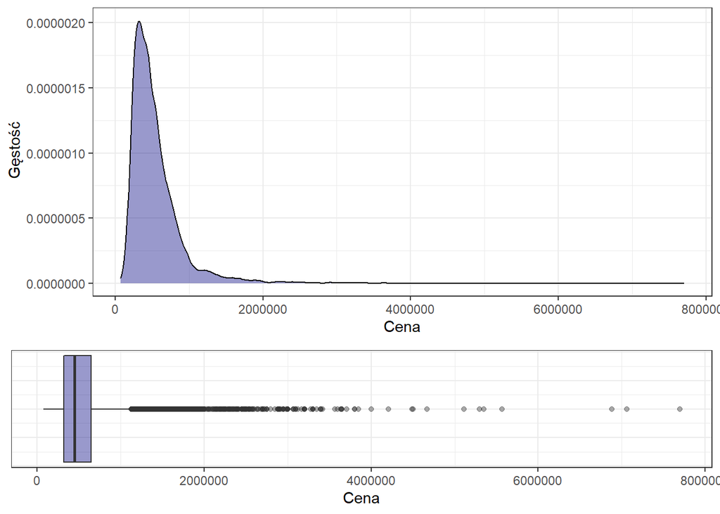

```r
p1 <- ggplot(dane, aes(x = price)) +
  theme_bw() +
  geom_density(fill = "navy", alpha = 0.4) +
  labs(x = "Cena", y = " Gęstość")

p2 <- ggplot(dane, aes(x = price)) +
  theme_bw() +
  geom_boxplot(fill = "navy", alpha = 0.4) +
  theme(axis.text.y = element_blank(), axis.ticks.y = element_blank()) +
  labs(x = "Cena")

grid.arrange(p1, p2, nrow = 2, heights = c(2, 1))
```

Dodatkowo poniżej zależności innych zmiennych od ceny nieruchmości.

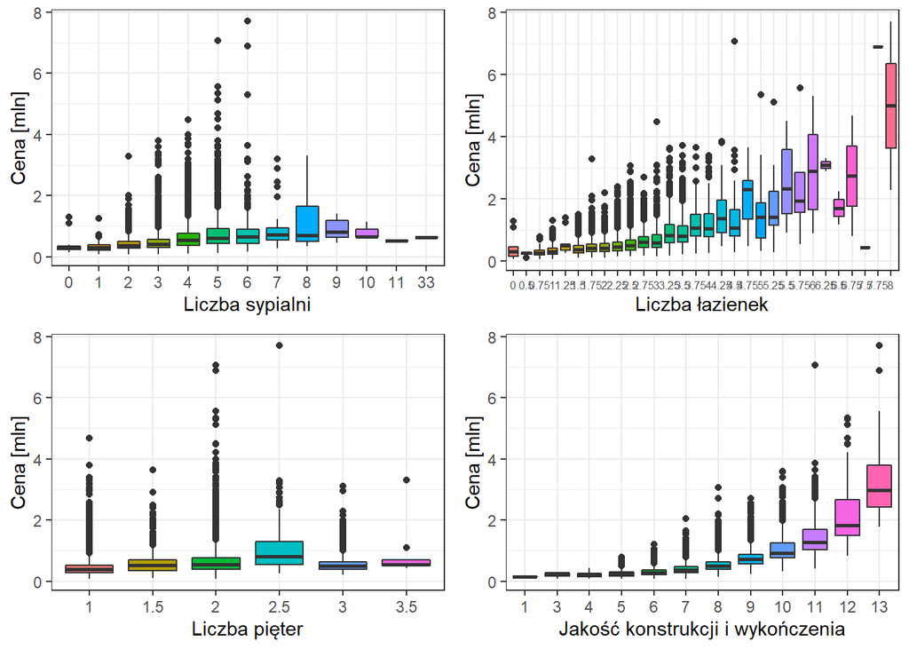

```r
p3 <- ggplot(dane, aes(x = as.factor(bedrooms), y = price/1000000, fill = as.factor(bedrooms))) +
  geom_boxplot() +
  theme_bw() +
  labs(x = "Liczba sypialni", y = "Cena [mln]", fill = "") +
  theme(legend.position = "none")

p4 <- ggplot(dane, aes(x = as.factor(bathrooms), y = price/1000000, fill = as.factor(bathrooms))) +
  geom_boxplot() +
  theme_bw() +
  labs(x = "Liczba łazienek", y = "Cena [mln]", fill = "") +
  theme(legend.position = "none", axis.text.x = element_text(size = 6))

p5 <- ggplot(dane, aes(x = as.factor(floors), y = price/1000000, fill = as.factor(floors))) +
  geom_boxplot() +
  theme_bw() +
  labs(x = "Liczba pięter", y = "Cena [mln]", fill = "") +
  theme(legend.position = "none")

p6 <- ggplot(dane, aes(x = as.factor(grade), y = price/1000000, fill = as.factor(grade))) +
  geom_boxplot() +
  theme_bw() +
  labs(x = "Jakość konstrukcji i wykończenia", y = "Cena [mln]", fill = "") +
  theme(legend.position = "none")

grid.arrange(p3, p4, p5, p6, nrow = 2, ncol = 2)
```

Zależność roku budowy nieruchomości od ceny. Ograniczenie do nieruchomości, których cena jest niższa niż 1 mln. Niewielki wzrost ceny dla obserwacji, które zostały zbudowane na początku XX wieku oraz początku XXI wieku.

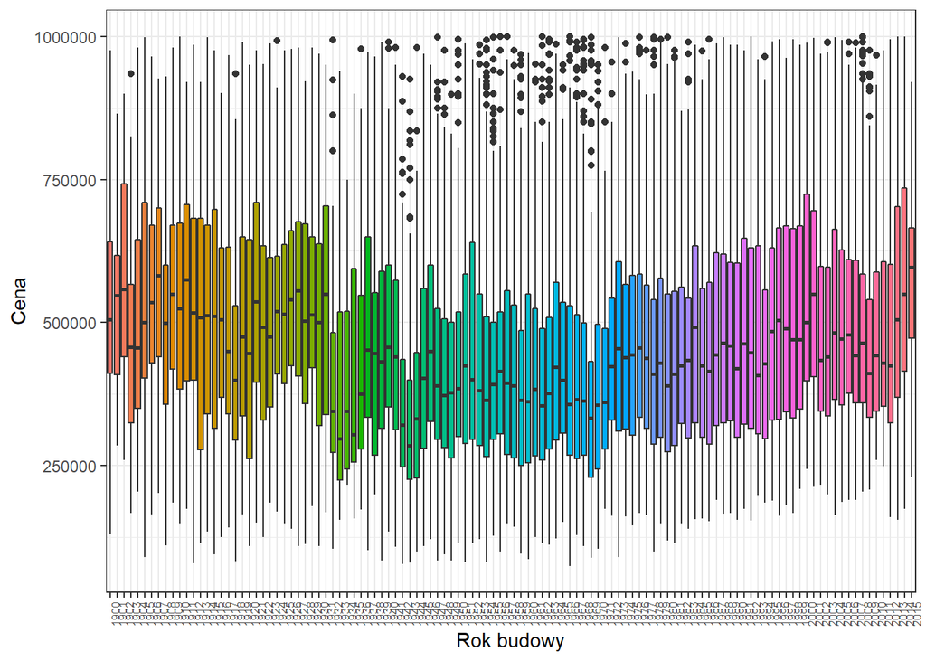

```r
ggplot(dane[dane$price < 1000000, ], aes(x = as.factor(yr_built), y = price, fill = as.factor(yr_built))) +
  geom_boxplot() +
  theme_bw() +
  labs(x = "Rok budowy", y = "Cena", fill = "") +
  theme(legend.position = "none") +
  theme(axis.text.x = element_text(angle = 90, hjust = 1, size = 6))
```

## Budowa modelu predykcyjnego (Ad 1)

Zbudowano model lasu losowego (`ranger`). Zmienna objaśniana to cena nieruchomości.

```r
## Modelowanie z mlr
library(mlr)
library(ranger)
## Dobór parametrów dla modelu random forest na podstawie metryki rmse
tsk <- makeRegrTask(data = dane_model, target = "price")
ps <- makeParamSet(
  makeIntegerParam("num.trees", lower = 50, upper = 1000),
  makeIntegerParam("mtry", lower = 1, upper = 4),
  makeIntegerLearnerParam("min.node.size", lower = 1, upper = 100))

ctrl <- makeTuneControlRandom(maxit = 100L)
rdesc <- makeResampleDesc("CV", iters = 3L)
res <- tuneParams("regr.ranger",
                 task = tsk,
                 resampling = rdesc,
                 par.set = ps,
                 control = ctrl,
                 measures = rmse)
lrn <- setHyperPars(makeLearner("regr.ranger"),
                   num.trees = res$x$num.trees,
                   mtry = res$x$mtry,
                   min.node.size = res$x$min.node.size)


## Trenowanie modelu
mod <- train(lrn, tsk)
```

### Predykcja dla obserwacji (Ad 2)

```r
task_pred = predict(mod, newdata = dane_model)
pred_values <- as.data.frame(task_pred)
```

## Wyjaśnienia

W celu wyjaśnień metodą LIME skorzystano z pakietu `lime`.

Budowanie obiektu `lime` oraz `explain` dla modelu `mlr` z pakietu `lime`.

```r
explain_mod <- lime(dane_model, mod, n_permutations = 2000)
```

### LIME dla obserwacji (Ad 3)

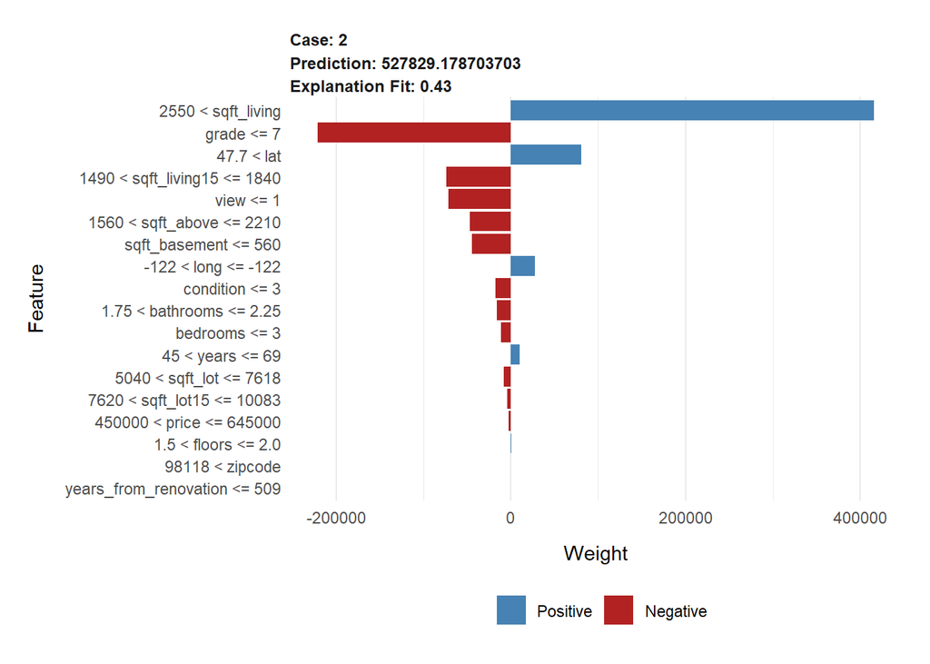

```r
expl <- explain(dane_model[2,], explain_mod, n_features = 18)
plot_features(expl)
```

### Jak stabilne są te wyjaśnienia? (Ad 4)

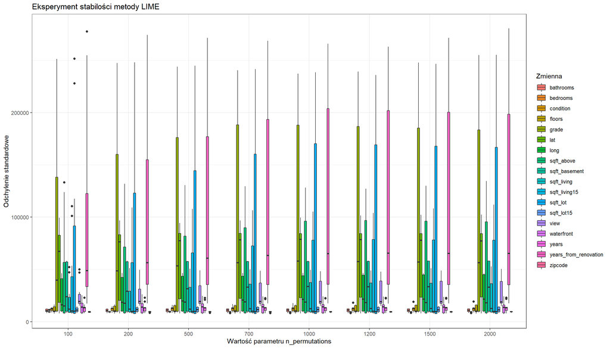

### Model regresji liniowej oraz LIME dla modelu regresji i modelu lasu losowego (Ad 5)

Poniżej wyjaśnienia LIME dla obserwacji oraz modelu lasu losowego i regresji liniowej.

```r
tsk <- makeRegrTask(data = dane_model, target = "price")
lrn <- makeLearner("regr.lm")
mod_lm <- train(lrn, tsk)
explain_mod_lm <- lime(dane_model, mod_lm)
```

#### Model lasu losowego

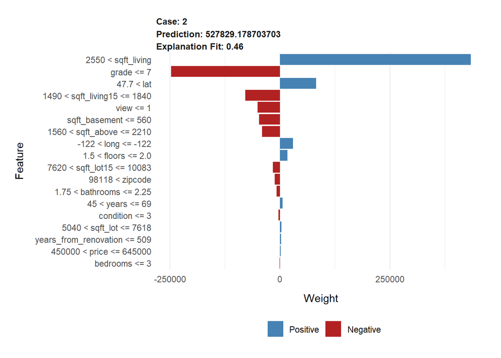

```r
expl_ranger <- explain(dane_model[2,], explain_mod, n_features = 1000)
plot_features(expl_ranger)
```

#### Model regresji liniowej

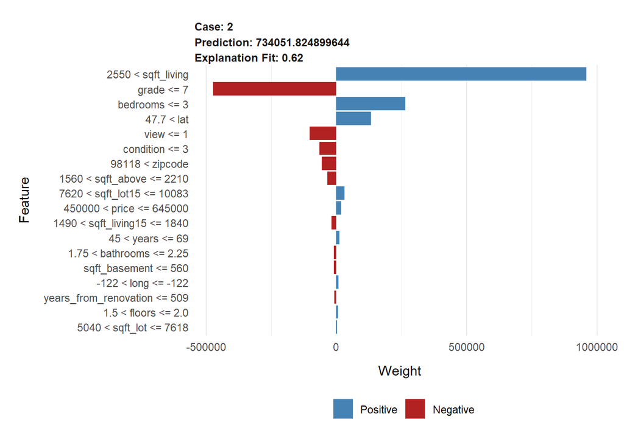

```r
expl_lm <- explain(dane_model[2,], explain_mod_lm, n_features = 1000)
plot_features(expl_lm)
```

Na poniższym wykresie ukazano różnice w wyjaśnieniach dla tej obserwacji. Zauważono znaczące różnice w wyjaśnieniach pod względem użytego modelu. Z drugiej storny oba modele wskazują takie same istotne zmienne, czyli `sqft_living` oraz `grade`. Odpowiednio powierzchnia użytkowa oraz jakość konstrukcji i wykończenia.

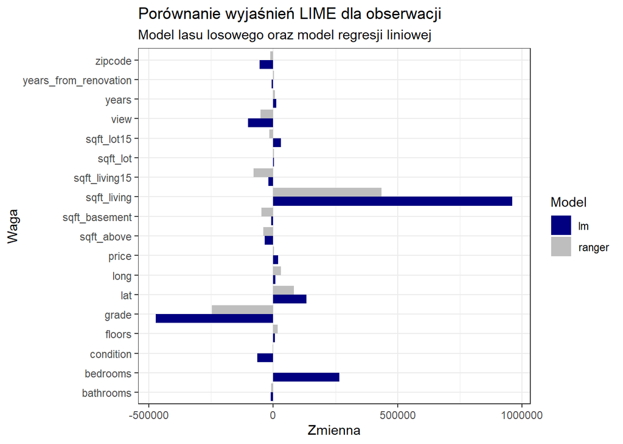

### Podsumowanie (Ad 6)

Metoda LIME jest oparta na idei przybliżenia złożonego modelu prostszym. Dzięki temu, prostszy model z mniejszą liczbą zmiennych objaśniających do zinterpretowania jest łatwiejszy do wyjaśnienia. Istnieją pewne ograniczenia, jednym z nich jest kwestia reprezentacji zmiennych ciagłych i kategorycznych. Jest kilka propozycji rozwiązania tego problemu, ale nie wybrano jednego konkretnego. Najbardziej użyteczne zastosowania LIME ograniczają się do danych wysokowymiarowych, czyli takich jak analiza obrazu czy tekstu.